# Feature extraction and interpretation from convolutional neural networks

Raphael Mourad, Maître de Conférences, Université Paul Sabatier

10/02/2021

## SETUP PROJECT FOLDER

Set up your project folder to your folder “atelier_INSERM”.

```r
knitr::opts_knit$set(root.dir = "/media/raphael/SSD2/atelier_INSERM")
knitr::opts_chunk$set(echo = TRUE)
```

## AIM OF THE SCRIPT

This script is used to extract and interpret the convolutional features from the trained CNN.

## LOAD LIBRARIES

Load R librairies. Remove suppressPackageStartupMessages() for debugging!

```r
suppressPackageStartupMessages(library(GenomicRanges))
suppressPackageStartupMessages(library(Biostrings))
suppressPackageStartupMessages(library(TFBSTools))
suppressPackageStartupMessages(library(JASPAR2020))
suppressPackageStartupMessages(library(tensorflow))
suppressPackageStartupMessages(library(keras))
suppressPackageStartupMessages(library(reticulate))
suppressPackageStartupMessages(library(motifStack))
suppressPackageStartupMessages(library(universalmotif))
```

## LOAD FUNCTIONS

```r
suppressPackageStartupMessages(source("scriptR/functions.R"))
```

## SOME PARAMETERS

Define parameters for the analysis:  
- peakSize is the resized peak size. For machine/deep learning, it is easier to work with peaks have the same size.  
- kpeaks is the number of best peaks used. Note that all peaks can also be used.  
- expe is the ChIP-seq experiment. For instance, CTCF for CTCF ChIP-seq or POL2 for RNA Polymerase 2 ChIP-seq experiment.

```r
peakSize=201
kpeaks=4000
expe="DNase"
DNAletters=c("A","C","G","T")
vocab_size=length(DNAletters)
```

## INPUT FILE NAMES

Set file names, which includes:  
- positive peaks from ChIP-seq and negative peaks from the control generator function genNullSeqs().  
- bed (genomic ranges) and fasta files (corresponding DNA sequences).

```r
fileBedPos=paste0("data/bed/",expe,"_GM12878_hg19_",kpeaks,"_pos.bed")
fileBedNeg=paste0("data/bed/",expe,"_GM12878_hg19_",kpeaks,"_neg.bed")
fileFastaPos=paste0("data/fasta/",expe,"_GM12878_hg19_",kpeaks,"_pos.fa")
fileFastaNeg=paste0("data/fasta/",expe,"_GM12878_hg19_",kpeaks,"_neg.fa")
```

## LOAD PROCESSED DATA

Load ChIP-seq and control fasta sequences:

```r
peakPos.seq=readDNAStringSet(fileFastaPos)
peakNeg.seq=readDNAStringSet(fileFastaNeg)
print(peakPos.seq)
```

```
## DNAStringSet object of length 4000:
##        width seq                                            names
##    [1]   201 AATGACCCACCAATCACATGCC...TGTAACACGAGAAAGCACATA chr1_1
##    [2]   201 TCATCACTAGACATCGTACTAC...GTAAATCTAACTTTCTTCCCA chr1_2
##    [3]   201 CCCTATTAGTGGGTGAACAATC...TGAGGCCCCGCTTTCACGGTC chr1_3
##    [4]   201 TTTGCTAGGCAGAATAGTAATG...ATAATTATGCCTCACAGGGAT chr5_4
##    [5]   201 CGGGTCTTCCAGGAGTCGGGTT...CCGCGCAGTCCGCCCGGAGGA chr11_5
##    ...   ... ...
## [3996]   201 AACAGGAAGTCACAGCACTCGA...CATGCATTACTCAGTGTGATA chr6_3996
## [3997]   201 GCGCCCCGCAGGCCCGCCCACT...CGCGAGGCCGGCCTGAGGGAG chr7_3997
## [3998]   201 GCCATTGCCGTCCACCCCGGAA...GTGGGCTAGTCTTCGGACGGC chr7_3998
## [3999]   201 GGACGCACAGGAAGCGAGGGCA...CATTTGAAATGTCTCTATCTG chr7_3999
## [4000]   201 CCTTGCGATTCCCTTCGCCACT...CGCTGATTGGCTGCCGAGACC chr7_4000
```

Bind positive and negative sequences, and make label:

```r
peakAll.seq=c(peakPos.seq,peakNeg.seq)
label=c(rep(1,length(peakPos.seq)),rep(0,length(peakNeg.seq)))
```

Shuffle sequence indices:

```r
idxS=sample(1:length(peakAll.seq))
peakAllS.seq=peakAll.seq[idxS]
labelS=label[idxS]
print(labelS[1:5])
```

```
## [1] 1 1 1 1 0
```

Split train and test indices:

```r
percTrain=0.7
idxTrain=1:(ceiling(length(labelS)*percTrain))
idxTest=(length(idxTrain)+1):length(labelS)
labelTrain=labelS[idxTrain]
labelTest=labelS[idxTest]
```

## LOAD MODEL

One hot encoding

```r
oneHotPos=convertOneHot(peakPos.seq)
```

Load CNN1 model

```r
file_model=paste0("results/model/CNN1_model_",expe,".hdf5")
model=load_model_hdf5(file_model)
```

## FEATURE EXTRACTION

Extract kernels from CNN1 convolutional layer object “model” should be the CNN1!

```r
conv1d_layer_model <- keras_model(inputs = model$input, outputs = get_layer(model, 'conv1d_cnn1')$output)
print(conv1d_layer_model)
```

```
## Model
## Model: "model"
## ________________________________________________________________________________
## Layer (type)                        Output Shape                    Param #
## ================================================================================
## conv1d_cnn1_input (InputLayer)      [(None, 201, 4)]                0
## ________________________________________________________________________________
## conv1d_cnn1 (Conv1D)                (None, 186, 128)                8320
## ================================================================================
## Total params: 8,320
## Trainable params: 8,320
## Non-trainable params: 0
## ________________________________________________________________________________
```

Get the kernel activation outputs

```r
conv1d_output <- predict(conv1d_layer_model, oneHotPos)
print(conv1d_output[1,1:5,1:5])
```

```
##             [,1] [,2] [,3] [,4] [,5]
## [1,] 0.005805468    0    0    0    0
## [2,] 0.000000000    0    0    0    0
## [3,] 0.058846354    0    0    0    0
## [4,] 0.000000000    0    0    0    0
## [5,] 0.000000000    0    0    0    0
```

```r
print(dim(conv1d_output)) # To see the size of the tensor
```

```
## [1] 4000  186  128
```

```r
kernelSize=peakSize-dim(conv1d_output)[2]+1
```

Convert kernels to Position Frequency Matrices (PFMs)

```r
activationThreshold=0.15
kernelPFMList=convertToPWMs(conv1d_output, peakPos.seq, activationThreshold)
```

```
## [1] 4000  128
```

```r
print(kernelPFMList)
```

```
## PFMatrixList of length 126
## names(126): kernel1 kernel2 kernel3 kernel4 ... kernel126 kernel127 kernel128
```

Plot first motif

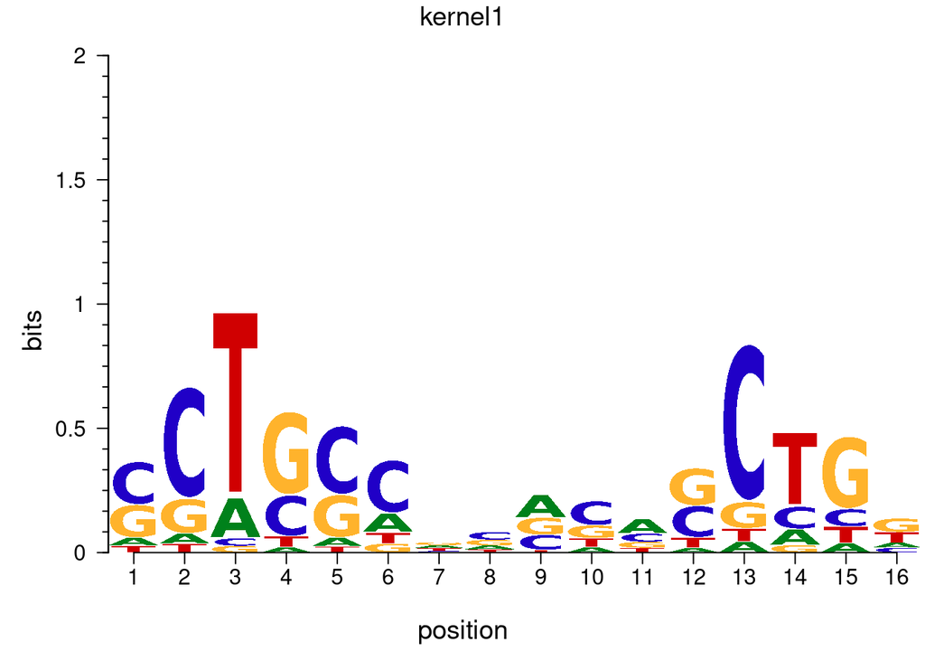

```r
motif1 <- new("pcm", mat=as.matrix(kernelPFMList[[1]]), name=ID(kernelPFMList[[1]]))
plot(motif1)
```

Trimming and filtering of motifs based on information content

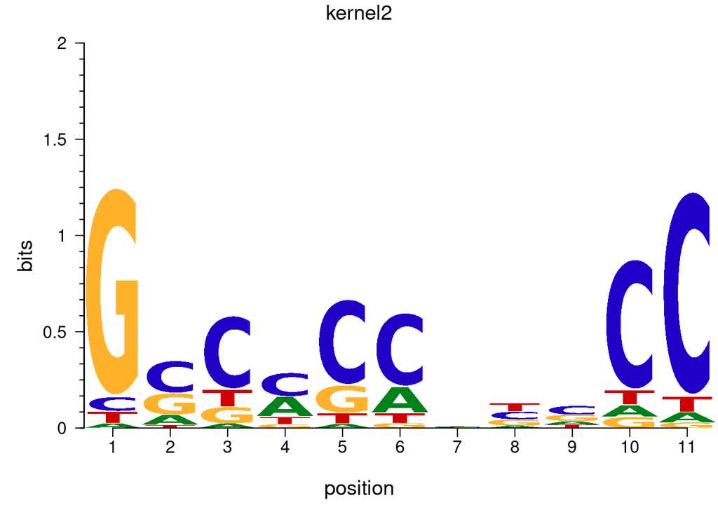

```r
ICthreshold=0.9
PFMTrimmedList=motifTrimming(kernelPFMList,ICthreshold)
motifTrimmed1 <- new("pcm", mat=as.matrix(PFMTrimmedList[[1]]), name=ID(PFMTrimmedList[[1]]))
plot(motifTrimmed1)
```

Export motifs for dimension reduction with RSAT matrix-clustering

```r
kernelPFMListUM=convert_motifs(PFMTrimmedList, class = "universalmotif-universalmotif")
write_jaspar(kernelPFMListUM,paste0("results/motif/trimmed_redundant_motifs_",expe,".jaspar"),overwrite=TRUE)
```

## FEATURE IMPORTANCE

Load root motifs

```r
rootMotifsUM=read_transfac(paste0("results/motif/root_motifs_",expe,".tf"))
rootMotifs=do.call(PFMatrixList,convert_motifs(rootMotifsUM, "TFBSTools-PFMatrix"))
print(rootMotifs)
```

```
## PFMatrixList of length 8
```

DNA motif counts

```r
motif_ix=matchMotifs(rootMotifs,peakAllS.seq,out="scores",p.cutoff=1e-4)
mcAllS=motifCounts(motif_ix)
```

```
## dimnames(.) <- NULL:  translated to
## dimnames(.) <- list(NULL,NULL)  <==>  unname(.)
## dimnames(.) <- NULL:  translated to
## dimnames(.) <- list(NULL,NULL)  <==>  unname(.)
## dimnames(.) <- NULL:  translated to
## dimnames(.) <- list(NULL,NULL)  <==>  unname(.)
```

```r
mcTrain=mcAllS[idxTrain,]
mcTest=mcAllS[idxTest,]
print(mcTrain[1:5,])
```

```
## 5 x 8 sparse Matrix of class "dgCMatrix"
##
## [1,] . . . 1 . . . .
## [2,] . . . . . 1 . .
## [3,] . . 1 . . . . .
## [4,] . . . . 1 . . .
## [5,] . . 1 . . . . .
```

Random forests

```r
dataRF_motif=data.frame(label=labelTrain,as(mcTrain,"matrix"))
RF_motif=ranger(label ~ .,data=dataRF_motif,importance="permutation")
predRF_motif=predict(RF_motif,data=data.frame(as(mcTest,"matrix")))$predictions
rocRF_motif=pROC::roc(as.factor(labelTest),predRF_motif,ci=T)
```

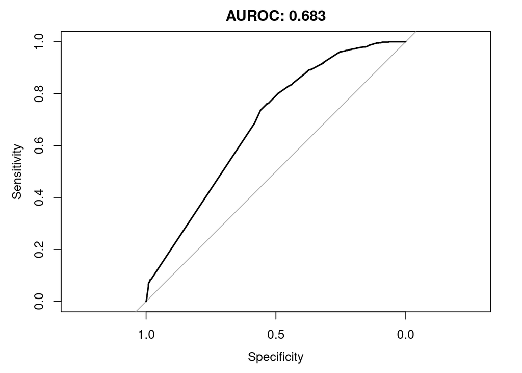

```r
plot(rocRF_motif,main=paste0("AUROC: ", round(pROC::auc(rocRF_motif),3)))
```

Variable importance

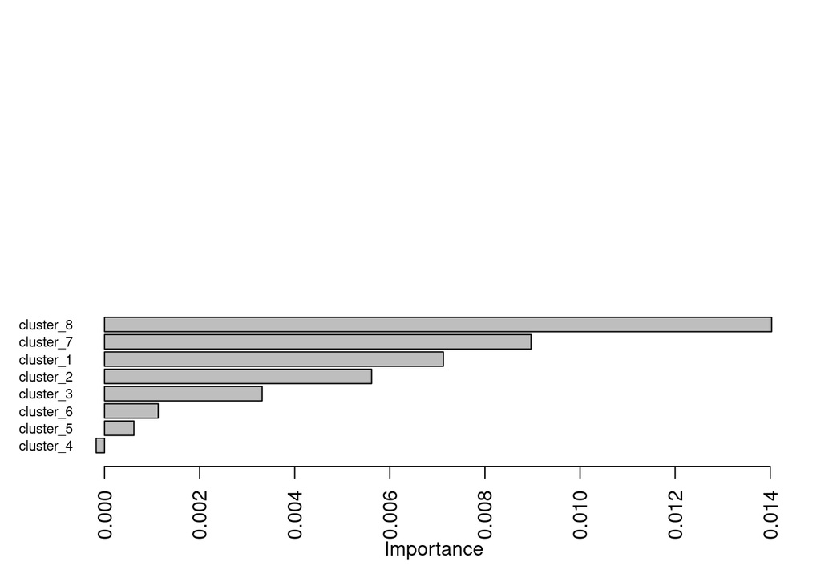

```r
motifID=ID(rootMotifs)
dataImportanceMotif=data.frame(motifID,importance=importance(RF_motif))
dataImportanceMotif=dataImportanceMotif[order(importance(RF_motif),decreasing=T)[1:20],]
dataImportanceMotif2=dataImportanceMotif[order(dataImportanceMotif[,2]),]
barplot(dataImportanceMotif2[,2],names.arg=dataImportanceMotif2[,1],cex.names=0.7,horiz=T,las=2,xlab="Importance")
```

## FEATURE (MOTIF) VISUALIZATION

Plot best motif logo from PFM matrix

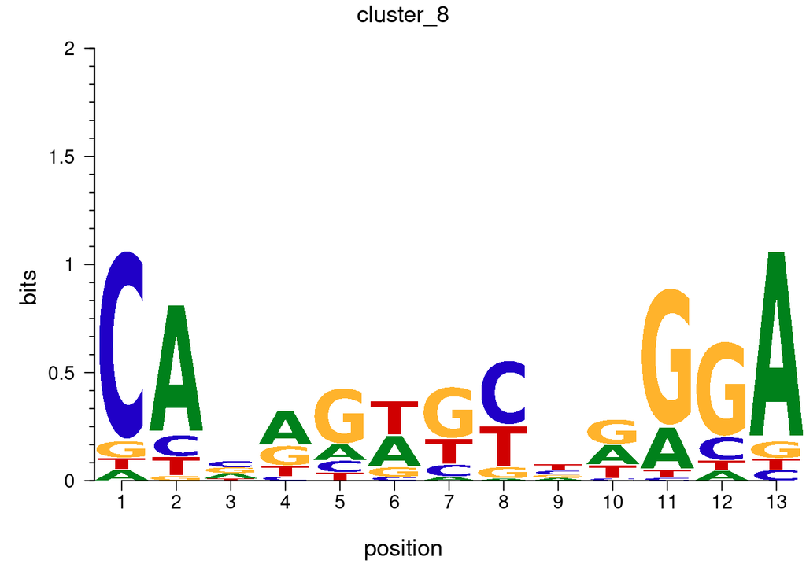

```r
rootMotifsMS=lapply(rootMotifs,function(x){new("pcm", mat=as.matrix(x), name=ID(x))})
idxBestRootMotif=which(ID(rootMotifs)==dataImportanceMotif[1,1])
plot(rootMotifsMS[[idxBestRootMotif]])
```

Plot motif clustering tree

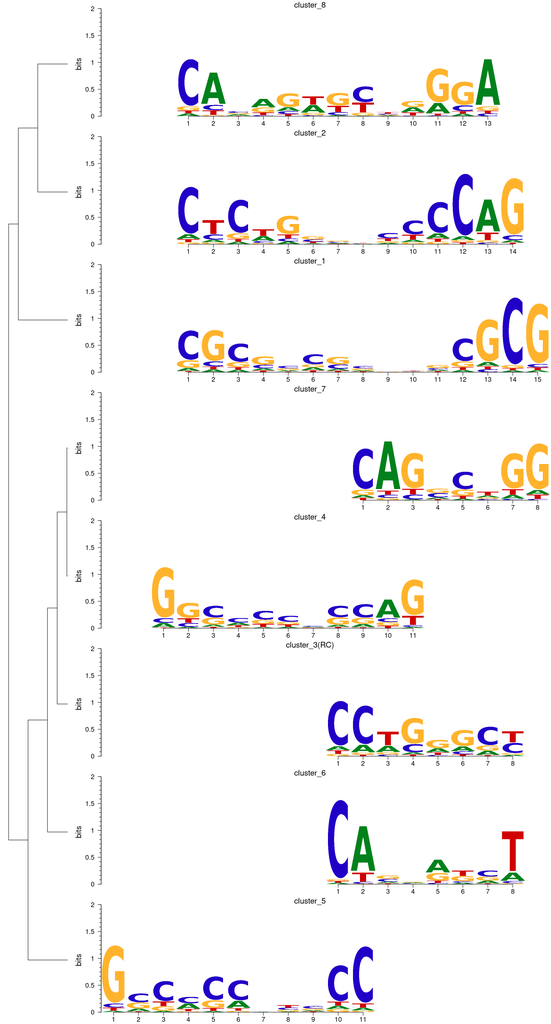

```r
file_plot_tree_motifs=paste0("results/motif/plot_tree_motifs_",expe,".pdf")
#pdf(file_plot_tree_motifs,30,200)
motifStack(rootMotifsMS, layout="tree")
```

```r
#dev.off()
```